# Regression Models

[output not shown]

[output not shown]

[output not shown]

[output not shown]

[output not shown]

[output not shown]

[output not shown]

[output not shown]

[output not shown]

[output not shown]

[output not shown]

[output not shown]

[output not shown]

[output not shown]

[output not shown]

[output not shown]

[output not shown]

[output not shown]

[output not shown]

[output not shown]

[output not shown]

[output not shown]

[output not shown]

[output not shown]

[output not shown]

[output not shown]

[output not shown]

[output not shown]

[output not shown]

[output not shown]

[output not shown]

[output not shown]

[output not shown]

[output not shown]

[output not shown]

[output not shown]

[output not shown]

[output not shown]

[output not shown]

[output not shown]

[output not shown]

[output not shown]

[output not shown]

[output not shown]

[output not shown]

[output not shown]

[output not shown]

[output not shown]

[output not shown]

[output not shown]

[output not shown]

[output not shown]

[output not shown]

[output not shown]

[output not shown]

[output not shown]

[output not shown]

[output not shown]

[output not shown]

[output not shown]

[output not shown]

[output not shown]

[output not shown]

[output not shown]

[output not shown]

[output not shown]

[output not shown]

[output not shown]

[output not shown]

[output not shown]

[output not shown]

[output not shown]

[output not shown]

[output not shown]

[output not shown]

[output not shown]

[output not shown]

[output not shown]

[output not shown]

[output not shown]

[output not shown]

[output not shown]

[output not shown]

[output not shown]

[output not shown]

[output not shown]

[output not shown]

[output not shown]

[output not shown]

[output not shown]

[output not shown]

[output not shown]

[output not shown]

[output not shown]

[output not shown]

[output not shown]

[output not shown]

[output not shown]

[output not shown]

[output not shown]

[output not shown]

[output not shown]

[output not shown]

[output not shown]

[output not shown]

[output not shown]

[output not shown]

[output not shown]

[output not shown]

[output not shown]

[output not shown]

[output not shown]

[output not shown]

[output not shown]

[output not shown]

[output not shown]

[output not shown]

[output not shown]

[output not shown]

[output not shown]

[output not shown]

[output not shown]

[output not shown]

```r
xgb_exp
```

```
## eXtreme Gradient Boosting
##
## 1252 samples
##    9 predictor
##
## No pre-processing
## Resampling: Cross-Validated (5 fold, repeated 3 times)
## Summary of sample sizes: 1002, 1000, 1001, 1002, 1003, 1002, ...
## Resampling results across tuning parameters:
##
##   eta  max_depth  colsample_bytree  subsample  nrounds  RMSE      Rsquared
##   0.3  1          0.6               0.50        50      1.596089  0.5284279
##   0.3  1          0.6               0.50       100      1.513002  0.5747785
##   0.3  1          0.6               0.50       150      1.480390  0.5935133
##   0.3  1          0.6               0.75        50      1.586874  0.5350716
##   0.3  1          0.6               0.75       100      1.513354  0.5751708
##   0.3  1          0.6               0.75       150      1.477608  0.5944516
##   0.3  1          0.6               1.00        50      1.589498  0.5348571
##   0.3  1          0.6               1.00       100      1.520329  0.5736246
##   0.3  1          0.6               1.00       150      1.483490  0.5929307
##   0.3  1          0.8               0.50        50      1.564013  0.5476935
##   0.3  1          0.8               0.50       100      1.490606  0.5882812
##   0.3  1          0.8               0.50       150      1.473058  0.5979284
##   0.3  1          0.8               0.75        50      1.563963  0.5484709
##   0.3  1          0.8               0.75       100      1.494617  0.5872914
##   0.3  1          0.8               0.75       150      1.463383  0.6024339
##   0.3  1          0.8               1.00        50      1.569104  0.5483887
##   0.3  1          0.8               1.00       100      1.505345  0.5822916
##   0.3  1          0.8               1.00       150      1.471868  0.5997300
##   0.3  2          0.6               0.50        50      1.446679  0.6117315
##   0.3  2          0.6               0.50       100      1.405495  0.6324349
##   0.3  2          0.6               0.50       150      1.402699  0.6354443
##   0.3  2          0.6               0.75        50      1.440257  0.6145332
##   0.3  2          0.6               0.75       100      1.394037  0.6381261
##   0.3  2          0.6               0.75       150      1.386549  0.6424309
##   0.3  2          0.6               1.00        50      1.420612  0.6267917
##   0.3  2          0.6               1.00       100      1.366604  0.6525557
##   0.3  2          0.6               1.00       150      1.350855  0.6598071
##   0.3  2          0.8               0.50        50      1.426703  0.6217244
##   0.3  2          0.8               0.50       100      1.407692  0.6318154
```

[output cut: 181 more lines]

```
##   1.1147127
##   1.0411590
##   1.0414798
##   1.0444225
##   1.0039821
##   0.9948153
##   0.9974059
##
## Tuning parameter 'gamma' was held constant at a value of 0
## Tuning
##  parameter 'min_child_weight' was held constant at a value of 1
## RMSE was used to select the optimal model using the smallest value.
## The final values used for the model were nrounds = 100, max_depth = 3, eta
##  = 0.3, gamma = 0, colsample_bytree = 0.8, min_child_weight = 1 and subsample
##  = 1.
```

```r
xgb_exp$bestTune
```

```
##    nrounds max_depth eta gamma colsample_bytree min_child_weight subsample
## 53     100         3 0.3     0              0.8                1         1
```

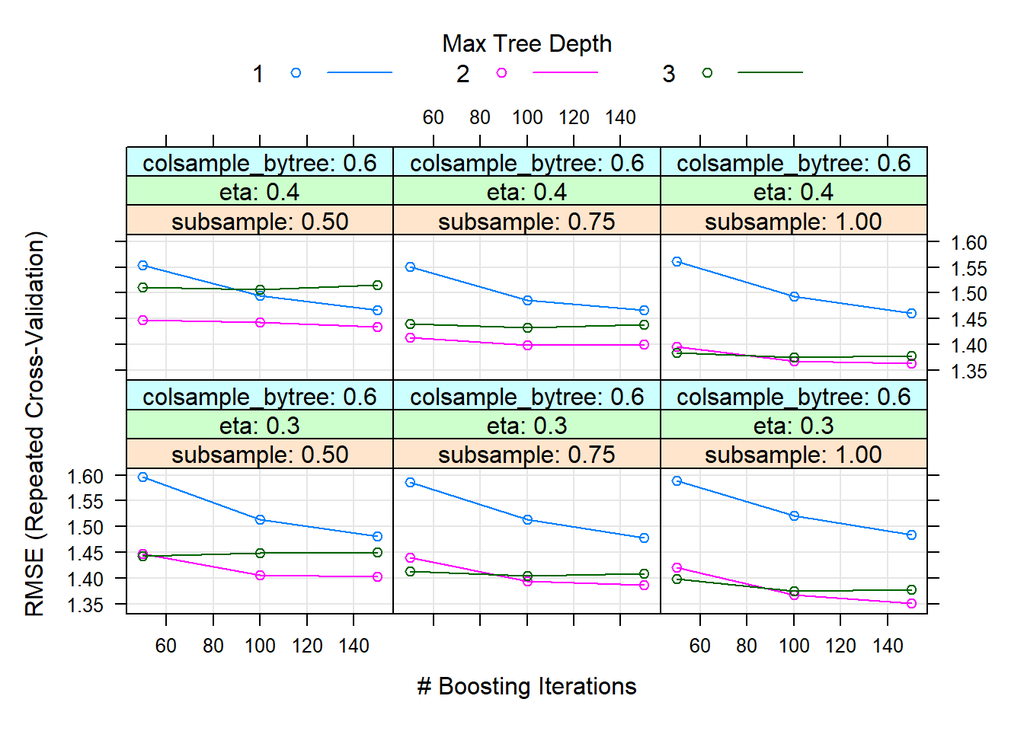

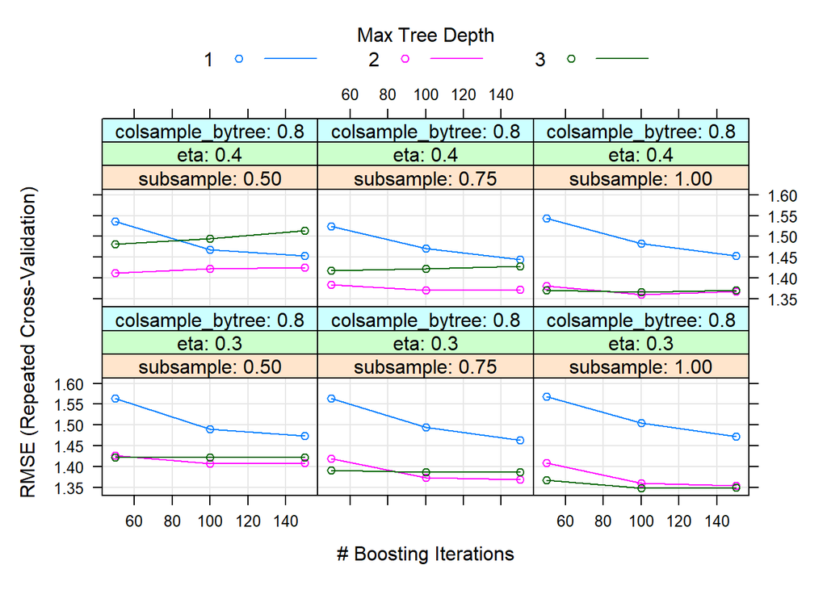

```r
plot(xgb_exp)
```

Huh, this one usually does better with a tree depth of 2. Let’s evaluate their r-squared and RMSE:

```r
max(xgb_base$results$Rsquared)
```

```
## [1] 0.6921338
```

```r
max(xgb_exp$results$Rsquared)
```

```
## [1] 0.6611116
```

```r
min(xgb_base$results$RMSE)
```

```
## [1] 1.281711
```

```r
min(xgb_exp$results$RMSE)
```

```
## [1] 1.347285
```

The base feature XGB is marginally better in terms of RMSE, but still doesn’t beat the linear models in terms of r-squared.

Let’s overheat my computer right quick and tune base XGB

```r
xgb_grid <- expand.grid(nrounds = seq(100, 700, by = 100),
                        max_depth = c(3, 4, 5),
                        eta = c(0.5*xgb_base$bestTune$eta, xgb_base$bestTune$eta),
                        gamma = xgb_base$bestTune$gamma,
                        colsample_bytree = xgb_base$bestTune$colsample_bytree,
                        min_child_weight = xgb_base$bestTune$min_child_weight,
                        subsample = xgb_base$bestTune$subsample)
```

```r
xgb_base_tune <- train(y ~ x1 + x2 + x3 + x4 + v1 + v2 + v3 + v4 + v5 + m,
                 data = df,
                 method = "xgbTree",
                 tuneGrid = xgb_grid,
                 metric = my_metric,
                 trControl = my_ctrl,
                 objective = 'reg:squarederror',
                 verbose = FALSE)
```

[output not shown]

[output not shown]

[output not shown]

[output not shown]

[output not shown]

[output not shown]

[output not shown]

[output not shown]

[output not shown]

[output not shown]

[output not shown]

[output not shown]

[output not shown]

[output not shown]

[output not shown]

[output not shown]

[output not shown]

[output not shown]

[output not shown]

[output not shown]

[output not shown]

[output not shown]

[output not shown]

[output not shown]

[output not shown]

[output not shown]

[output not shown]

[output not shown]

[output not shown]

[output not shown]

[output not shown]

[output not shown]

[output not shown]

[output not shown]

[output not shown]

[output not shown]

[output not shown]

[output not shown]

[output not shown]

[output not shown]

[output not shown]

[output not shown]

[output not shown]

[output not shown]

[output not shown]

[output not shown]

[output not shown]

[output not shown]

[output not shown]

[output not shown]

[output not shown]

[output not shown]

[output not shown]

[output not shown]

[output not shown]

[output not shown]

[output not shown]

[output not shown]

[output not shown]

[output not shown]

[output not shown]

[output not shown]

[output not shown]

[output not shown]

[output not shown]

[output not shown]

[output not shown]

[output not shown]

[output not shown]

[output not shown]

[output not shown]

[output not shown]

[output not shown]

[output not shown]

[output not shown]

[output not shown]

[output not shown]

[output not shown]

[output not shown]

[output not shown]

[output not shown]

[output not shown]

[output not shown]

[output not shown]

[output not shown]

[output not shown]

[output not shown]

[output not shown]

[output not shown]

[output not shown]

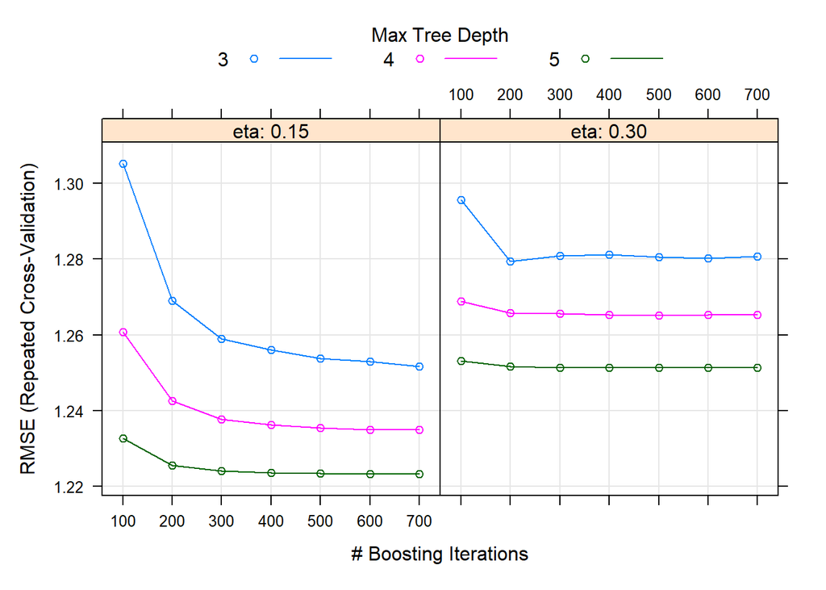

```r
plot(xgb_base_tune)
```

Nice tune achieved with depth of 5, many iterations. However, it still doesn’t beat the spline basis linear model in terms of RMSE…

###Support Vector Machine

```r
svm <- train(y ~ x1 + x2 + x3 + x4 + v1 + v2 + v3 + v4 + v5 + m + z,
             data = df,
             method = "svmRadial",
             metric = my_metric,
             preProcess = c("center", "scale"),
             trControl = my_ctrl,
             verbose = FALSE)
svm
```

```
## Support Vector Machines with Radial Basis Function Kernel
##
## 1252 samples
##   11 predictor
##
## Pre-processing: centered (14), scaled (14)
## Resampling: Cross-Validated (5 fold, repeated 3 times)
## Summary of sample sizes: 1001, 1002, 1002, 1002, 1001, 1002, ...
## Resampling results across tuning parameters:
##
##   C     RMSE      Rsquared   MAE
##   0.25  1.610430  0.5571695  1.196866
##   0.50  1.479121  0.6082312  1.110597
##   1.00  1.404173  0.6362375  1.060826
##
## Tuning parameter 'sigma' was held constant at a value of 0.04732483
## RMSE was used to select the optimal model using the smallest value.
## The final values used for the model were sigma = 0.04732483 and C = 1.
```

Okay, decent performance actually. I tried with base features, got poor performance, then added Z and got better performance.

###Partial Least Squares Let’s put some correlated variables in here

```r
pls_grid <- expand.grid(ncomp = 1:5)
pls <- train(y ~ x1 + x2 + x3 + x4 + v1 + v2 + v3 + v4 + v5 + m + z,
             data = df,
             method = "pls",
             metric = my_metric,
             tuneGrid = pls_grid,
             preProcess = c("center", "scale"),
             trControl = my_ctrl,
             verbose = FALSE)
pls
```

```
## Partial Least Squares
##
## 1252 samples
##   11 predictor
##
## Pre-processing: centered (14), scaled (14)
## Resampling: Cross-Validated (5 fold, repeated 3 times)
## Summary of sample sizes: 1002, 1002, 1001, 1002, 1001, 1003, ...
## Resampling results across tuning parameters:
##
##   ncomp  RMSE      Rsquared   MAE
##   1      2.150775  0.1384235  1.659014
##   2      2.058007  0.2112369  1.593847
##   3      1.928012  0.3066702  1.487490
##   4      1.866625  0.3500128  1.417819
##   5      1.862156  0.3534665  1.415410
##
## RMSE was used to select the optimal model using the smallest value.
## The final value used for the model was ncomp = 5.
```

Pretty poor performance actually…

##Compare models!

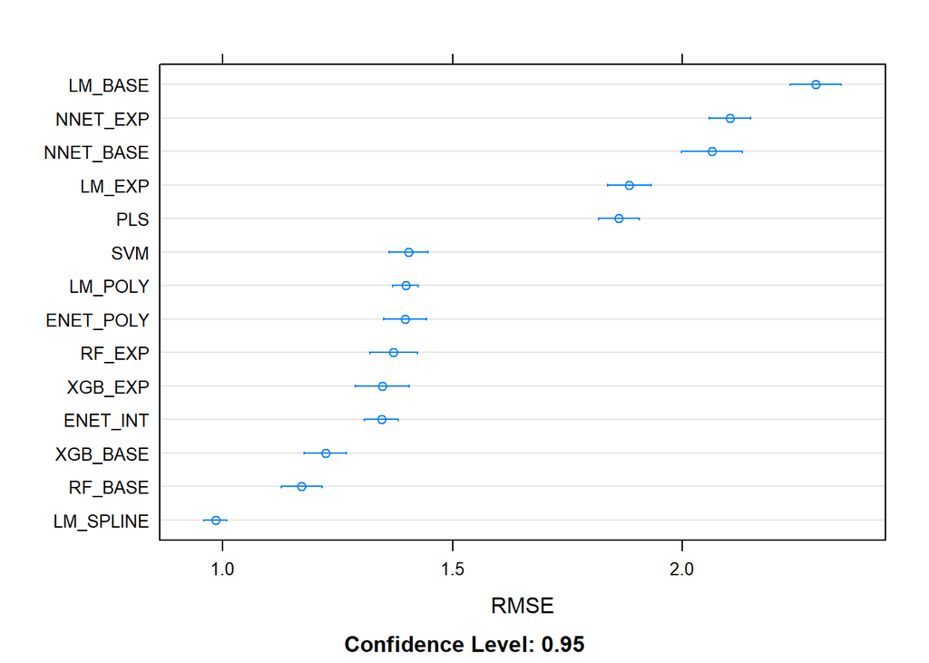

```r
my_results <- resamples(list(LM_BASE = base_feature_lm,
                             LM_EXP = expanded_feature_lm,
                             LM_POLY = basis_poly_lm,
                             LM_SPLINE = basis_spline_lm,
                             ENET_INT = enet_full_tune,
                             ENET_POLY = enet_poly,
                             NNET_BASE = neural_net_base,
                             NNET_EXP = neural_net_expanded_tune,
                             RF_BASE = random_forest_base,
                             RF_EXP = random_forest_expanded,
                             XGB_BASE = xgb_base_tune,
                             XGB_EXP = xgb_exp,
                             SVM = svm,
                             PLS = pls
                             ))
dotplot(my_results, metric = "RMSE")
```

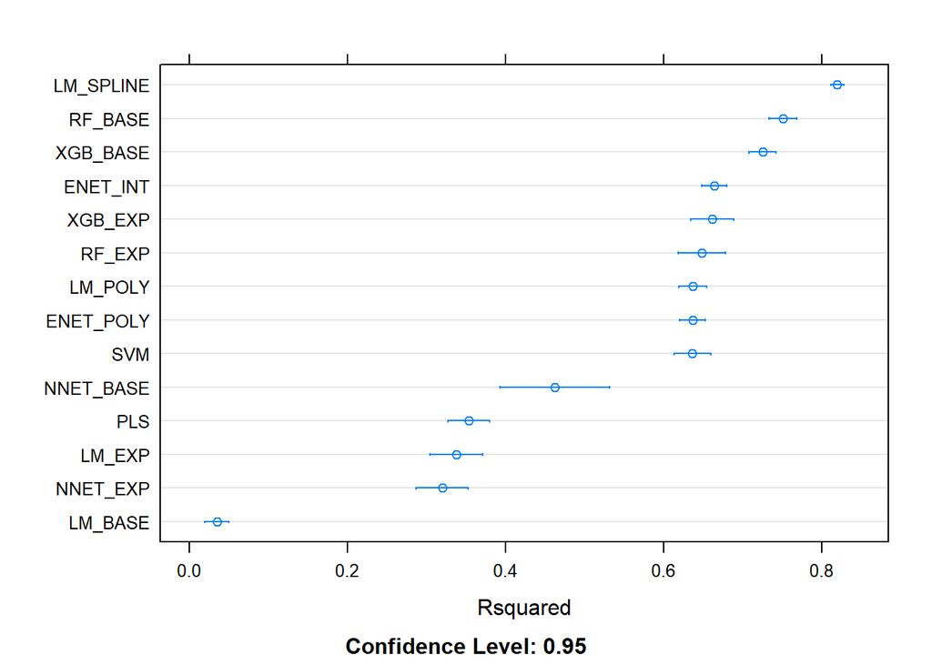

```r
dotplot(my_results, metric = "Rsquared")
```

##In conclusion, the spline basis function linear model using x1, x2, and z is still the best model!

Save models..

```r
save(basis_spline_lm, file = "spline_basis_model.Rdata")
save(xgb_base_tune, file = "xgb_base.Rdata")
save(xgb_exp, file = "xgb_exp.Rdata")
```